# Assignment 5 Prediction

Zhulin Yu

11/14/2017

Load Libraries

```r
library(rpart)
library(party)
```

Load Data

```r
D1 = read.csv("intelligent_tutor.csv")
```

Here are all the variables:

id - student id prior_prob_count - The number of problems a student has done in the system prior to the surrent session

score - The score the student achieved in the current session

hints - The number of hints the student requested in the current session

hint.y - Whether or not the student asked for hints in the current session

complete - Whether or not the student completed the current session

prior_prob_count - total number of problems solved in previous sessions

prior_percent_correct - percentage of correct in previous sessions

action - The action suggested by the system to a teacher about a given student based on their performance: 1 = Ask Teacher; 2 = Start New Session; 3 = Give up.

# Part I, Build a classification tree to predict behavior

```r
c.tree <- rpart(action ~ hint.y + complete, method="class", data=D1) #Notice the standard R notion for a formula X ~ Y

#Look at the error of this tree
printcp(c.tree)
```

```
##
## Classification tree:
## rpart(formula = action ~ hint.y + complete, data = D1, method = "class")
##
## Variables actually used in tree construction:
## [1] complete hint.y
##
## Root node error: 250/378 = 0.66138
##
## n= 378
##
##      CP nsplit rel error xerror     xstd
## 1 0.052      0     1.000  1.072 0.035325
## 2 0.012      1     0.948  0.972 0.037264
## 3 0.010      2     0.936  0.980 0.037138
```

```r
#Plot the tree
post(c.tree, file = "tree.ps", title = "Session Completion Action: 1 - Ask teacher, 2 - Start new session, 3 - Give up")
```

# Part II, Regression Tree

Build a regression tree to predict students’ final scores, which determine what tpye of intervention is preferred.

First, Visulaize score data to decide “leaves”

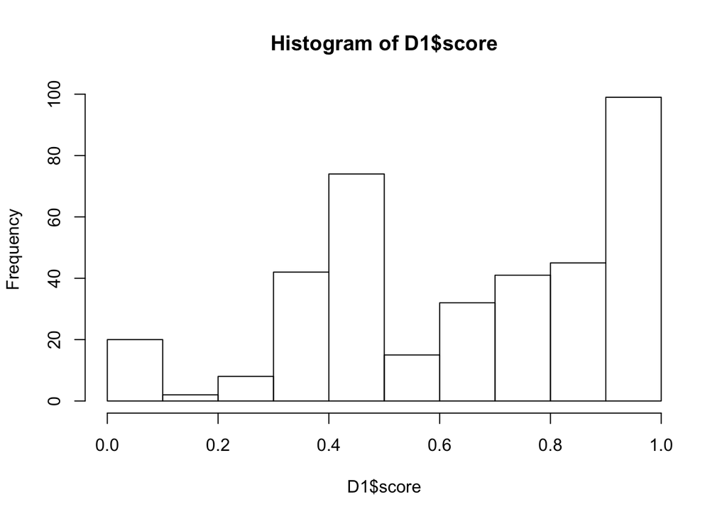

```r
hist(D1$score)
```

Define “Leaves”: score <= 0.4, intervene; score between 0.4 and 0.8, monitor; score >= 0.8, no action.

Then generate the regression tree by using ctree. And plot.

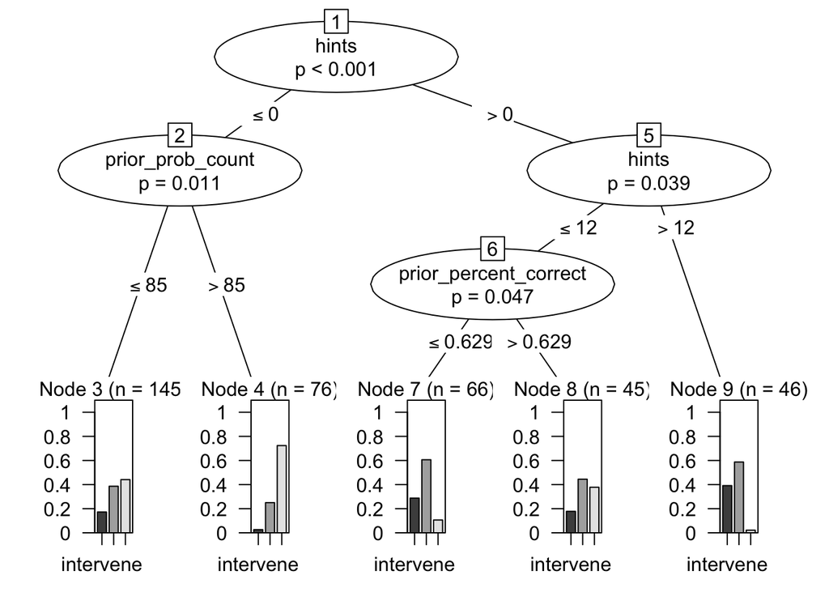

```r
D1$advice <- ifelse(D1$score <=0.4, "intervene", ifelse(D1$score > 0.4 & D1$score <=0.8, "monitor", "no action"))
score_ctree <- ctree(factor(advice) ~ prior_prob_count + prior_percent_correct + hints, D1)
plot(score_ctree)
```

As shown in the figure above, intervention decisions would be made in the following procedure:

1, If one has asked for hints:

[output not shown]

2, If he/she never asked for hints:

```
2.1, And he/she has solved 85 or less problems before, we might want to monitor or take no action.

2.2, And he/she has solved more than 85 problems, we would take no action.
```

To conclude, I would recommend to pay more attention to number of hints (hints) and total number of problems solved before (prior_prob_count).

### Using the regression tree to predict upon new data

```r
# import new dataset
D2 = read.csv("intelligent_tutor_new.csv")

#Generate predicted advice for new students based on tree generated from old students
D2$prediction <- predict(score_ctree, D2)
```

# Part III

Compare the predicted advice with the actual advice that these studnts received. What is the difference between the observed and predicted results?

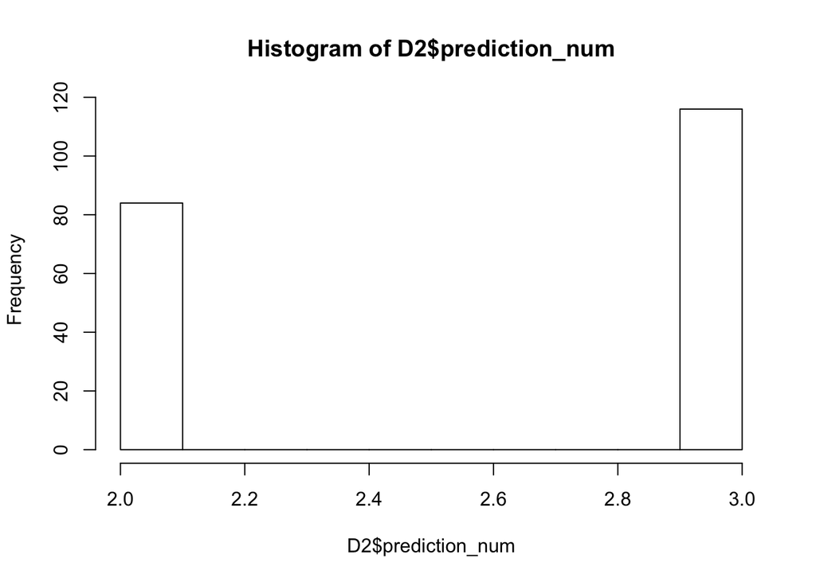

```r
# Recode "no action" to 3; "monitor" to 2; and "intervene" to 1.
D2$prediction_num[D2$prediction == "no action"] = 3
D2$prediction_num[D2$prediction == "monitor"] = 2
D2$prediction_num[D2$prediction == "intervene"] = 1

# Then visualize the distribution of the three actions.
hist(D2$prediction_num)
```